# 8H1

Sophie Castel

2018-07-01

Q: *Run the model below and then inspect the posterior distribution and explain what it is accomplishing.*

$\verb+mp <- map2stan(+$  
$\verb+ alist(+$  
$\verb+ a ~ dnorm(0,1),+$  
$\verb+ b ~ dcauchy(0,1)+$  
$\verb+ ),+$  
$\verb+ data=list(y=1),+$  
$\verb+ start=list(a=0,b=0),+$  
$\verb+ iter=1e4, warmup=100, WAIC=FALSE+$  
$\verb+)+$

Inspecting the code above, we can first see that a likelihood has not been defined. In fact, we have only defined prior distributions for two parameters *a* and *b*, where:

> *a* follows a **standard Normal** distribution ($\mu = 0$, $\sigma = 1$)  
> *b* follows a **standard Cauchy** distribution ($x_{0} = 0$, $\gamma = 1$)

Second, we define a dataframe with one element, y=1.

Third, we specify a starting point of zero for each parameter. This gives the computer a rough location of the estimates.

Finally, we know that Markov Chains approximate using iterative sampling. Convince youself that $\verb+iter = 1e4+$ and $\verb+warmup = 100+$ are sufficient.

Q: *Compare the samples for the parameters a and b. Can you explain the different trace plots, using what you know about the Cauchy distribution?*

Since there is no likelihood, we actually sample from a posterior distribution which is just composed of the priors.

```r
precis(mp)
```

```
##    Mean StdDev lower 0.89 upper 0.89 n_eff Rhat
## a  0.01   0.99      -1.56       1.60  9900    1
## b -2.65  60.97      -6.31       6.16   567    1
```

Comparing the $\verb+n_eff+$ values, the effective sample size for *b* is much smaller than that of *a*. Recall that ideally,

$$\verb+n_eff+ \approx \verb+iter+-\verb+warmup+$$
$$\verb+n_eff+ \approx 9900$$

So, we speculate if the chain for *b* is inefficient. Checking the trace plots may give us a better idea of what happened:

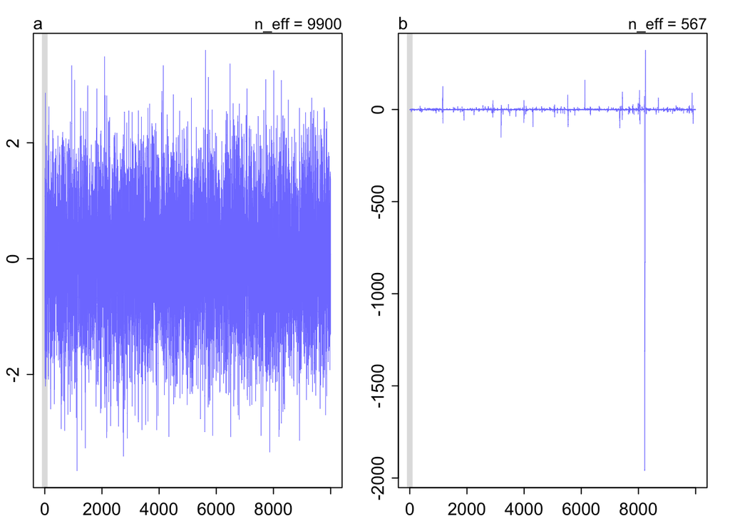

A difference between the two plots is immediately obvious:

The trace plot for *a* (left) is what we typically expect from a Gaussian parameter: stationary and well-mixing. The trace plot for *b* (right) shows that occasionally a large estimate of the parameter value is drawn.

Recall the shape of the standard Cauchy distribution (red) compared to the standard normal (black):

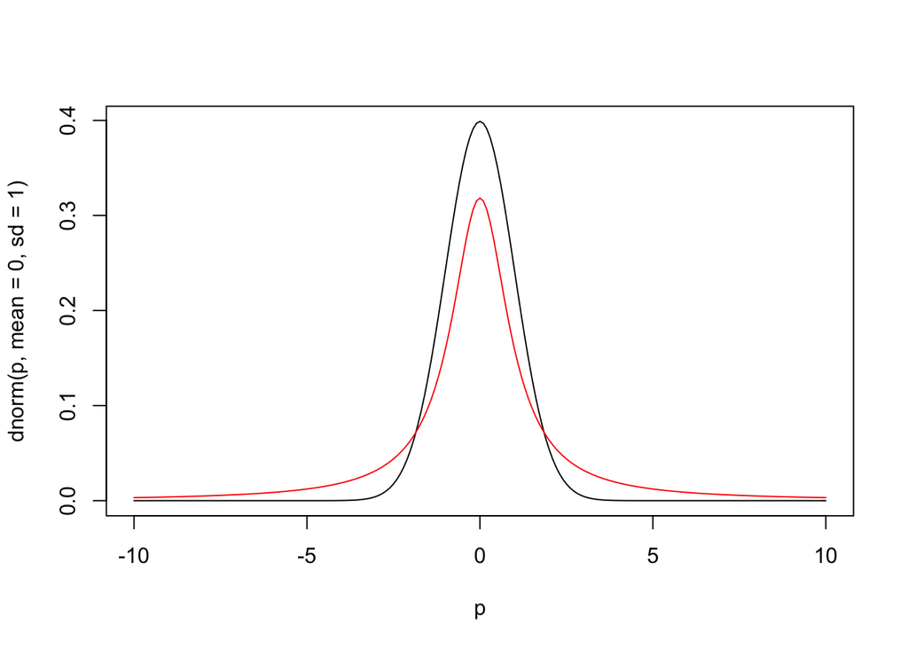

```r
p<-seq(-10,10,by=0.1)
plot(p, dnorm(p, mean = 0, sd = 1),type="l")
lines(p, dcauchy(p, location = 0, scale = 1), col="red")
```

See that the Cauchy distribution has heavier tails that do not converge to zero as $n\to\infty$ (this is why the Cauchy distribution has undefined mean and variance). This explains the occasional spikes in the trace plot, representing the path taken by the Markov Chain when a sample estimate is drawn from way out in the tails.

More clearly, see below the resemblance between randomly generated points from each distribution with sample size $\approx \verb+n_eff+$ and the trace plots for each respective parameter.

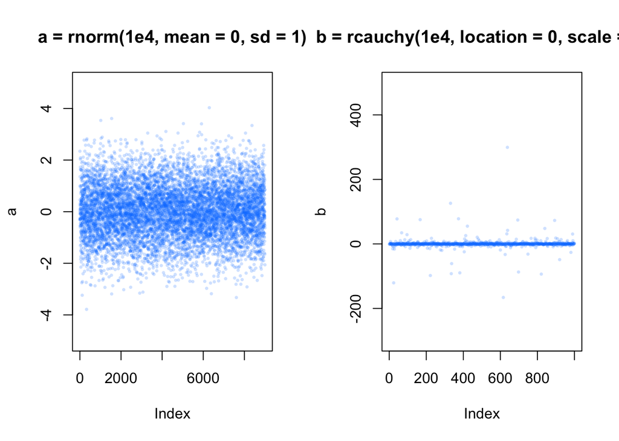

```r
a = rnorm(9000, mean = 0, sd = 1)
b = rcauchy(1000, location = 0, scale = 1)

par(mfrow = c(1,2))
plot(a, type = "p", col = rgb(red = 0, green = 0.5, blue = 1, alpha = 0.2),
     pch = 16, cex = 0.5, main = "a = rnorm(1e4, mean = 0, sd = 1)", ylim = c(-5,5))
plot(b, type = "p", col = rgb(red = 0, green = 0.5, blue = 1, alpha = 0.2),
     pch = 16, cex = 0.5, main = "b = rcauchy(1e4, location = 0, scale = 1)", ylim = c(-300,500))
```